# Home Value/Housing Prices in the DMV area from 2021-2023 analysis and report

Team 7

2024-10-26

# Step 1

```r
#Chunk one, let's use this for basic EDA, initial understanding of the data
housing_data <- read.csv("housingdata.csv")
#Fardin
str(housing_data)
```

```
## 'data.frame':    43308 obs. of  9 variables:
##  $ RegionID  : int  67182 67732 67180 66126 66705 66843 67730 66135 67010 66683 ...
##  $ SizeRank  : int  80 140 165 174 199 268 275 277 321 322 ...
##  $ RegionName: int  22193 23464 22191 20002 20906 21234 23462 20011 21740 20878 ...
##  $ RegionType: chr  "zip" "zip" "zip" "zip" ...
##  $ State     : chr  "VA" "VA" "VA" "DC" ...
##  $ City      : chr  "Woodbridge" "Virginia Beach" "Woodbridge" "Washington" ...
##  $ Metro     : chr  "Washington-Arlington-Alexandria, DC-VA-MD-WV" "Virginia Beach-Norfolk-Newport News, VA-NC" "Washington-Arlington-Alexandria, DC-VA-MD-WV" "Washington-Arlington-Alexandria, DC-VA-MD-WV" ...
##  $ month     : chr  "2021-01-31" "2021-01-31" "2021-01-31" "2021-01-31" ...
##  $ ZHVI      : num  382710 298449 368262 671416 380993 ...
```

```r
summary(housing_data)
```

```
##     RegionID         SizeRank       RegionName     RegionType
##  Min.   : 66125   Min.   :   80   Min.   :20001   Length:43308
##  1st Qu.: 66825   1st Qu.: 6391   1st Qu.:21215   Class :character
##  Median : 67339   Median :13358   Median :22639   Mode  :character
##  Mean   : 67591   Mean   :13672   Mean   :22511
##  3rd Qu.: 67835   3rd Qu.:20293   3rd Qu.:23847
##  Max.   :399556   Max.   :39992   Max.   :24656
##
##     State               City              Metro              month
##  Length:43308       Length:43308       Length:43308       Length:43308
##  Class :character   Class :character   Class :character   Class :character
##  Mode  :character   Mode  :character   Mode  :character   Mode  :character
##
##
##
##
##       ZHVI
##  Min.   :  25919
##  1st Qu.: 209760
##  Median : 316930
##  Mean   : 358347
##  3rd Qu.: 448365
##  Max.   :2829491
##  NA's   :1496
```

Our dataset has 43308 observations We’ve also observed 9 variables. The most important variable is ZHVI which stands for Zillow Home Value Index. We have null values for ZHVI. There are a few other interesting things about the dataset. Including, the minimum ZHVI for all three regions throughout 2021-2023 is just 25,919. The maximum is 2,829,491.

# Step 2

**Break down the dataset by regions.**

```r
#Using code we group the ZHVIs for the data together by the regions/states, DC, MD, and VA


dc_data <- subset(housing_data, State == "DC")
summary(dc_data)
```

```
##     RegionID        SizeRank       RegionName     RegionType
##  Min.   :66125   Min.   :  174   Min.   :20001   Length:792
##  1st Qu.:66130   1st Qu.: 1281   1st Qu.:20006   Class :character
##  Median :66136   Median : 3792   Median :20012   Mode  :character
##  Mean   :66137   Mean   : 5937   Mean   :20014
##  3rd Qu.:66142   3rd Qu.: 8424   3rd Qu.:20019
##  Max.   :66155   Max.   :23188   Max.   :20037
##     State               City              Metro              month
##  Length:792         Length:792         Length:792         Length:792
##  Class :character   Class :character   Class :character   Class :character
##  Mode  :character   Mode  :character   Mode  :character   Mode  :character
##
##
##
##       ZHVI
##  Min.   : 249195
##  1st Qu.: 454537
##  Median : 594026
##  Mean   : 650863
##  3rd Qu.: 790203
##  Max.   :1343857
```

```r
md_data <- subset(housing_data, State == "MD")
summary(md_data)
```

```
##     RegionID        SizeRank       RegionName     RegionType
##  Min.   :66494   Min.   :  199   Min.   :20601   Length:15228
##  1st Qu.:66645   1st Qu.: 4985   1st Qu.:20814   Class :character
##  Median :66802   Median :11963   Median :21154   Mode  :character
##  Mean   :66803   Mean   :13070   Mean   :21226
##  3rd Qu.:66961   3rd Qu.:20373   3rd Qu.:21663
##  Max.   :67111   Max.   :39992   Max.   :21921
##
##     State               City              Metro              month
##  Length:15228       Length:15228       Length:15228       Length:15228
##  Class :character   Class :character   Class :character   Class :character
##  Mode  :character   Mode  :character   Mode  :character   Mode  :character
##
##
##
##
##       ZHVI
##  Min.   :  52473
##  1st Qu.: 294152
##  Median : 395340
##  Mean   : 420935
##  3rd Qu.: 493668
##  Max.   :2829491
##  NA's   :468
```

```r
va_data <- subset(housing_data, State == "VA")
summary(va_data)
```

```
##     RegionID         SizeRank       RegionName     RegionType
##  Min.   : 66207   Min.   :   80   Min.   :20105   Length:27288
##  1st Qu.: 67380   1st Qu.: 7504   1st Qu.:22733   Class :character
##  Median : 67702   Median :14464   Median :23424   Mode  :character
##  Mean   : 68073   Mean   :14233   Mean   :23302
##  3rd Qu.: 68016   3rd Qu.:20456   3rd Qu.:24148
##  Max.   :399556   Max.   :39992   Max.   :24656
##
##     State               City              Metro              month
##  Length:27288       Length:27288       Length:27288       Length:27288
##  Class :character   Class :character   Class :character   Class :character
##  Mode  :character   Mode  :character   Mode  :character   Mode  :character
##
##
##
##
##       ZHVI
##  Min.   :  25919
##  1st Qu.: 175627
##  Median : 269728
##  Mean   : 314345
##  3rd Qu.: 384696
##  Max.   :1477492
##  NA's   :1028
```

Maryland and Virginia are the only of the three that has NA’s with a total of 468 NAs’and 1028 NA’s. The most expensive home in the dataset is located in Maryland.

# Step 3

**Finding the average ZHVI of each region over all three years as a whole**

```r
#Chunk three, further breakdown

#Average ZHVI of dc housing over all 3 years
mean_dc <- mean(dc_data$ZHVI, na.rm = TRUE)
mean_dc
```

```
## [1] 650862.8
```

```r
#Average ZHVI of va housing over all 3 years
mean_va <- mean(va_data$ZHVI, na.rm = TRUE)
mean_va
```

```
## [1] 314345.1
```

```r
#Average ZHVI of md housing over all 3 years
mean_md <- mean(md_data$ZHVI, na.rm = TRUE)
mean_md
```

```
## [1] 420934.9
```

We can see the average ZHVI from 2021-2023 was the largest in DC (650863), Maryland(420935) and then Virginia(314345).(Yonathan)

# Step 4

**Separating the DC, Maryland, and Virginia data by year**

```r
#Create column 'Year' by taking the first 4 characters of the variable 'month'
dc_data$Year <- substr(dc_data$month, 1, 4)
va_data$Year <- substr(va_data$month, 1, 4)
md_data$Year <- substr(md_data$month, 1, 4)

#Creating subsets of dc data by year
dc_data_2021 <- subset(dc_data, Year == "2021")
dc_data_2022 <- subset(dc_data, Year == "2022")
dc_data_2023 <- subset(dc_data, Year == "2023")

#Finding average ZHVI of dc by year
mean_dc_2021 <- mean(dc_data_2021$ZHVI, na.rm = TRUE)
mean_dc_2022 <- mean(dc_data_2022$ZHVI, na.rm = TRUE)
mean_dc_2023 <- mean(dc_data_2023$ZHVI, na.rm = TRUE)

#Creating subsets of VA data by year
va_data_2021 <- subset(va_data, Year == "2021")
va_data_2022 <- subset(va_data, Year == "2022")
va_data_2023 <- subset(va_data, Year == "2023")


#Finding average ZHVI of VA by year
mean_va_2021 <- mean(va_data_2021$ZHVI, na.rm = TRUE)
mean_va_2022 <- mean(va_data_2022$ZHVI, na.rm = TRUE)
mean_va_2023 <- mean(va_data_2023$ZHVI, na.rm = TRUE)


#Creating subsets of MD data by year
md_data_2021 <- subset(md_data, Year == "2021")
md_data_2022 <- subset(md_data, Year == "2022")
md_data_2023 <- subset(md_data, Year == "2023")


#Finding average ZHVI of MD by year
mean_md_2021 <- mean(md_data_2021$ZHVI, na.rm = TRUE)
mean_md_2022 <- mean(md_data_2022$ZHVI, na.rm = TRUE)
mean_md_2023 <- mean(md_data_2023$ZHVI, na.rm = TRUE)
```

# Step 5

**Finding the average ZHVI of each reagion for each given year**

```r
#Comparing values from chunk four
options(scipen = 999)

#Average ZHVI of DC for years 2021-2023
mean_dc_2021
```

```
## [1] 643242.4
```

```r
mean_dc_2022
```

```
## [1] 662297.9
```

```r
mean_dc_2023
```

```
## [1] 647048
```

```r
#Average ZHVI of VA for years 2021-2023
mean_va_2021
```

```
## [1] 293828.3
```

```r
mean_va_2022
```

```
## [1] 319719
```

```r
mean_va_2023
```

```
## [1] 328925
```

```r
#Average ZHVI of MD for years 2021-2023
mean_md_2021
```

```
## [1] 400197.8
```

```r
mean_md_2022
```

```
## [1] 426661.3
```

```r
mean_md_2023
```

```
## [1] 434221.3
```

From this we observe the average ZHVI in DC wasn’t always increasing it went from 643,242 in 2021 to 662,298 in 2022 and then back down to 647,048 in 2023

Virginia however, was always increasing. Going from 293,828 to 319,719 in 2022 and 328,925 in 2023

Maryland is the same with the average ZHVI going from 400,198 to 426,621 and 434,221 in 2023.

# Step 6

**Plotting the data from chunk 4 and 5**

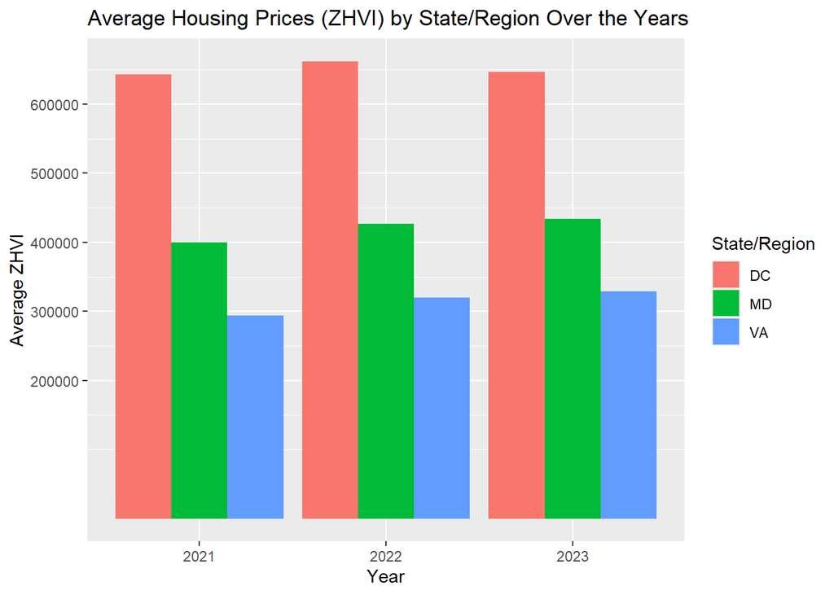

```r
#Plotting ZHVI for each region by year
library(ggplot2)

#Creating a data frame so all the data is put into one for it to be able to be plotted
combined_data <- rbind(dc_data, md_data, va_data)

ggplot(combined_data, aes(x = substr(month, 1, 4), y = ZHVI, fill = State)) +
  geom_bar(stat = "summary", fun = "mean", position = "dodge") +
  labs(
    title = "Average Housing Prices (ZHVI) by State/Region Over the Years",
    x = "Year",
    y = "Average ZHVI",
    fill = "State/Region"
  ) +
  scale_y_continuous(
    breaks = seq(200000, 650000, by = 100000)  #Making the scale smaller than the default
  )
```

# Step 7

**First statistical testing on the ZHVI of the three regions from 2021-2023 as a whole**

```r
# statistical testing the average home price for all three states/regions using the combined data


anova_result <- aov(ZHVI ~ State, data = combined_data)
summary(anova_result)
```

```
##                Df           Sum Sq        Mean Sq F value              Pr(>F)
## State           2  176430119586369 88215059793184    2040 <0.0000000000000002
## Residuals   41809 1807677066576806    43236553531
##
## State       ***
## Residuals
## ---
## Signif. codes:  0 '***' 0.001 '**' 0.01 '*' 0.05 '.' 0.1 ' ' 1
## 1496 observations deleted due to missingness
```

```r
tukey_result <- TukeyHSD(anova_result)
tukey_result
```

```
##   Tukey multiple comparisons of means
##     95% family-wise confidence level
##
## Fit: aov(formula = ZHVI ~ State, data = combined_data)
##
## $State
##            diff       lwr       upr p adj
## MD-DC -229927.9 -247703.1 -212152.7     0
## VA-DC -336517.7 -354093.6 -318941.8     0
## VA-MD -106589.8 -111603.2 -101576.4     0
```

With a p-value below 0.05, we can reject the null hypothesis that the means of the ZHVI for the three regions/states are equal. After doing a post-hoc test, we can see the average housing price(ZHVI) in Maryland is 229,928 less than DC. Housing price in VA is 336,518 less than DC. And VA is 106,590 cheaper than MD. There are statistically significant differences in ZHVI between all of the regions. (Yonathan)

# Step 8

**Statistical testing on the ZHVI of each region for each given year**

```r
#Creating sets of data with all regions for each given year within the range of 2021-2023
all_2021 <- rbind(dc_data_2021, va_data_2021, md_data_2021)

all_2022 <- rbind(dc_data_2022, va_data_2022, md_data_2022)

all_2023 <- rbind(dc_data_2023, va_data_2023, md_data_2023)


#Anova test for the year 2021
anova_2021 <- aov(ZHVI ~ State, data = all_2021)
summary(anova_2021)
```

```
##                Df          Sum Sq        Mean Sq F value              Pr(>F)
## State           2  59338707573329 29669353786664   786.3 <0.0000000000000002
## Residuals   13507 509672481278906    37733951379
##
## State       ***
## Residuals
## ---
## Signif. codes:  0 '***' 0.001 '**' 0.01 '*' 0.05 '.' 0.1 ' ' 1
## 926 observations deleted due to missingness
```

```r
#Anova test for the year 2022
anova_2022 <- aov(ZHVI ~ State, data = all_2022)
summary(anova_2022)
```

```
##                Df          Sum Sq        Mean Sq F value              Pr(>F)
## State           2  60523907204418 30261953602209   668.6 <0.0000000000000002
## Residuals   14096 638036288407547    45263641346
##
## State       ***
## Residuals
## ---
## Signif. codes:  0 '***' 0.001 '**' 0.01 '*' 0.05 '.' 0.1 ' ' 1
## 337 observations deleted due to missingness
```

```r
#Anova test for the year 2023
anova_2023 <- aov(ZHVI ~ State, data = all_2023)
summary(anova_2023)
```

```
##                Df          Sum Sq        Mean Sq F value              Pr(>F)
## State           2  56065382893278 28032691446639   611.4 <0.0000000000000002
## Residuals   14200 651097282551804    45851921306
##
## State       ***
## Residuals
## ---
## Signif. codes:  0 '***' 0.001 '**' 0.01 '*' 0.05 '.' 0.1 ' ' 1
## 233 observations deleted due to missingness
```

```r
#Post HOC test for 2021
tukey_result2021 <- TukeyHSD(anova_2021)
tukey_result2021
```

```
##   Tukey multiple comparisons of means
##     95% family-wise confidence level
##
## Fit: aov(formula = ZHVI ~ State, data = all_2021)
##
## $State
##            diff       lwr        upr p adj
## MD-DC -243044.6 -271853.1 -214236.14     0
## VA-DC -349414.1 -377863.8 -320964.31     0
## VA-MD -106369.4 -114660.5  -98078.31     0
```

```r
#Post HOC test for 2022
tukey_result2022 <- TukeyHSD(anova_2022)
tukey_result2022
```

```
##   Tukey multiple comparisons of means
##     95% family-wise confidence level
##
## Fit: aov(formula = ZHVI ~ State, data = all_2022)
##
## $State
##            diff       lwr        upr p adj
## MD-DC -235636.6 -267121.8 -204151.30     0
## VA-DC -342579.0 -373727.9 -311430.03     0
## VA-MD -106942.4 -115752.5  -98132.32     0
```

```r
#Post HOC test for 2023
tukey_result2023 <- TukeyHSD(anova_2023)
tukey_result2023
```

```
##   Tukey multiple comparisons of means
##     95% family-wise confidence level
##
## Fit: aov(formula = ZHVI ~ State, data = all_2023)
##
## $State
##            diff       lwr        upr p adj
## MD-DC -212826.7 -244510.3 -181143.15     0
## VA-DC -318123.0 -349470.1 -286775.82     0
## VA-MD -105296.2 -114130.9  -96461.56     0
```

Every year has a p-value below 0.05.

We observe a difference of 243,045 in average ZHVI of DC-MD homes, an average ZHVI difference of 349414 in VA-DC homes, and a difference of 106369 in average ZHVI of VA-MD homes for the year 2021.

For 2022 we observe a difference of 235,637 in average ZHVI between MD-DC homes, 342579 between VA-DC homes, and 106942 between VA-MD homes.

For 2023 we observe a 212827 diff between MD-DC homes, 318123 for VA-DC homes, and 105296 for VA-MD homes.

All years and regions had p-values below 0.05 so there are significant differences between all the avg housing prices between every region regardless of the year. (Yonathan)

# Step 9

**Further statistical testing**

```r
#ANOVA testing the average ZHVI of a region in one year versus the same region in the other years of the data
#We decided to take this step on Dr.Morris' recommendation following our first presentation of the data.

anova_dc_all_years <- aov(ZHVI ~ Year, data = dc_data)
summary(anova_dc_all_years)
```

```
##              Df         Sum Sq     Mean Sq F value Pr(>F)
## Year          2    53693577384 26846788692   0.399  0.671
## Residuals   789 53023462731979 67203374819
```

```r
anova_md_all_years <- aov(ZHVI ~ Year, data = md_data)
summary(anova_md_all_years)
```

```
##                Df          Sum Sq       Mean Sq F value             Pr(>F)
## Year            2   3058381965858 1529190982929   31.49 0.0000000000000226 ***
## Residuals   14757 716675732205102   48565137372
## ---
## Signif. codes:  0 '***' 0.001 '**' 0.01 '*' 0.05 '.' 0.1 ' ' 1
## 468 observations deleted due to missingness
```

```r
anova_va_all_years <- aov(ZHVI ~ Year, data = va_data)
summary(anova_va_all_years)
```

```
##                Df           Sum Sq       Mean Sq F value              Pr(>F)
## Year            2    5758938795317 2879469397659   73.47 <0.0000000000000002
## Residuals   26257 1029106857301172   39193619123
##
## Year        ***
## Residuals
## ---
## Signif. codes:  0 '***' 0.001 '**' 0.01 '*' 0.05 '.' 0.1 ' ' 1
## 1028 observations deleted due to missingness
```

The p-value for DC is above 0.05, meaning there is no significant difference in the average ZHVI of DC between the years 2021,2022, and 2023.

The p-value for md and va were both below 0.05. This means we reject the null hypothesis and that there is a significant difference in the average ZHVI of of MD for at least one of the years (2021-2023) compared to the others. This result is the same for VA. (Yonathan)

#Step 10

**Tukey Test for Maryland and Virginia all years ANOVA test**

```r
#Tukey Tests for the p-values below 0.05

tukey_md <- TukeyHSD(anova_md_all_years)
print(tukey_md)
```

```
##   Tukey multiple comparisons of means
##     95% family-wise confidence level
##
## Fit: aov(formula = ZHVI ~ Year, data = md_data)
##
## $Year
##                diff       lwr      upr     p adj
## 2022-2021 26463.570 15956.675 36970.46 0.0000000
## 2023-2021 34023.521 23534.509 44512.53 0.0000000
## 2023-2022  7559.951 -2711.616 17831.52 0.1957859
```

```r
tukey_va <- TukeyHSD(anova_va_all_years)
print(tukey_va)
```

```
##   Tukey multiple comparisons of means
##     95% family-wise confidence level
##
## Fit: aov(formula = ZHVI ~ Year, data = va_data)
##
## $Year
##                diff       lwr      upr     p adj
## 2022-2021 25890.613 18854.556 32926.67 0.0000000
## 2023-2021 35096.705 28074.006 42119.40 0.0000000
## 2023-2022  9206.092  2222.606 16189.58 0.0056859
```

The result for Maryland confirms that the average ZHVI in the state in the year 2022 was significantly higher than in 2021. The same goes for the average ZHVI in MD from 2023 being significantly higher than 2021. However, the average ZHVI for Maryland in 2023 is not significantly higher than the average ZHVI in 2022.

For Virginia the average ZHVI in 2022 was significantly higher than in 2021. The averge ZHVI in 2023 is significantly higher than in 2021. The average ZHVI in 2023 is also significantly higher than in 2022.

# Step 11

**Comparison of ZHVI Across Regions**

```r
# Load necessary libraries
library(ggplot2)
library(dplyr)
# Convert 'month' to date format
housing_data$month <- as.Date(housing_data$month, format="%Y-%m-%d")

# Check for missing ZHVI values
missing_data <- sum(is.na(housing_data$ZHVI))
cat("Missing ZHVI values: ", missing_data, "\n")
```

```
## Missing ZHVI values:  1496
```

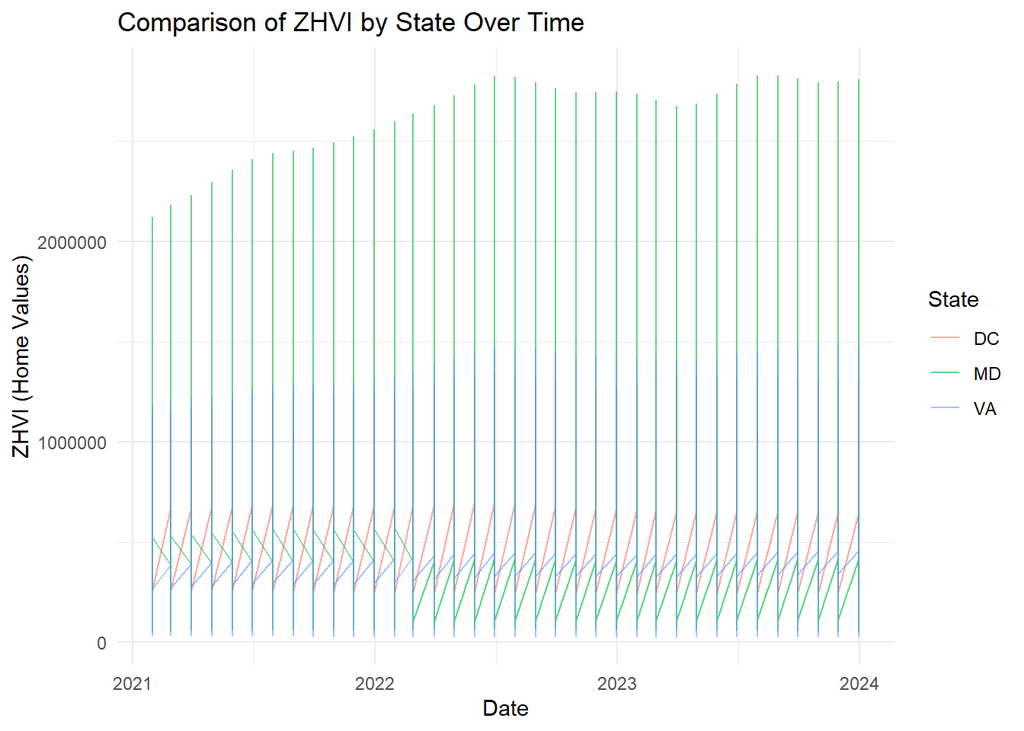

```r
# 2. Filter data to include only non-missing ZHVI values
data_filtered <- housing_data[!is.na(housing_data$ZHVI), ]

# 3. Compare ZHVI by State over Time
ggplot(data_filtered, aes(x = month, y = ZHVI, color = State)) +
  geom_line(alpha = 0.6) +
  labs(title = "Comparison of ZHVI by State Over Time", x = "Date", y = "ZHVI (Home Values)") +
  theme_minimal()
```

It indicates a positively inclined housing market in the DC, MD and VA regions. While the home values in DC were seen to be consistently high, the other states have also seen significant appreciation in the recent years.

# Step 12

**ZHVI Over Time**

```r
# Load necessary libraries
library(ggplot2)
library(dplyr)

# 3. Summary statistics of ZHVI
summary(housing_data$ZHVI)
```

```
##    Min. 1st Qu.  Median    Mean 3rd Qu.    Max.    NA's
##   25919  209760  316930  358347  448365 2829491    1496
```

```r
# 4. Missing data visualization
missing_data <- colSums(is.na(housing_data))
print(missing_data)
```

```
##   RegionID   SizeRank RegionName RegionType      State       City      Metro
##          0          0          0          0          0          0          0
##      month       ZHVI
##          0       1496
```

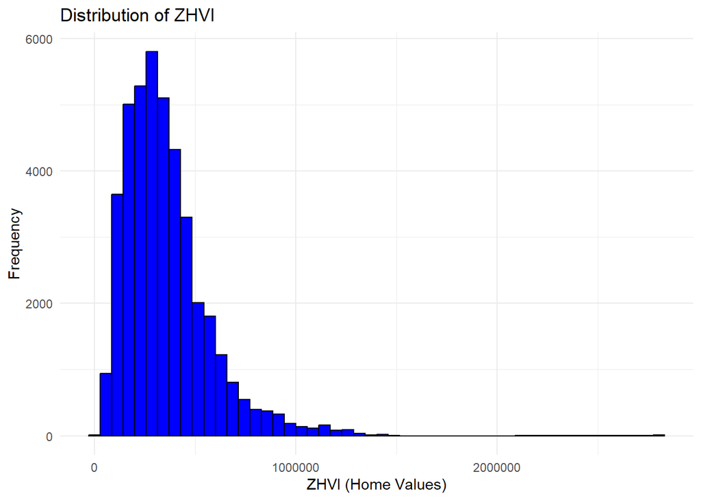

```r
# 5. Distribution of ZHVI
ggplot(housing_data, aes(x = ZHVI)) +
  geom_histogram(bins = 50, fill = "blue", color = "black") +
  labs(title = "Distribution of ZHVI", x = "ZHVI (Home Values)", y = "Frequency") +
  theme_minimal()
```

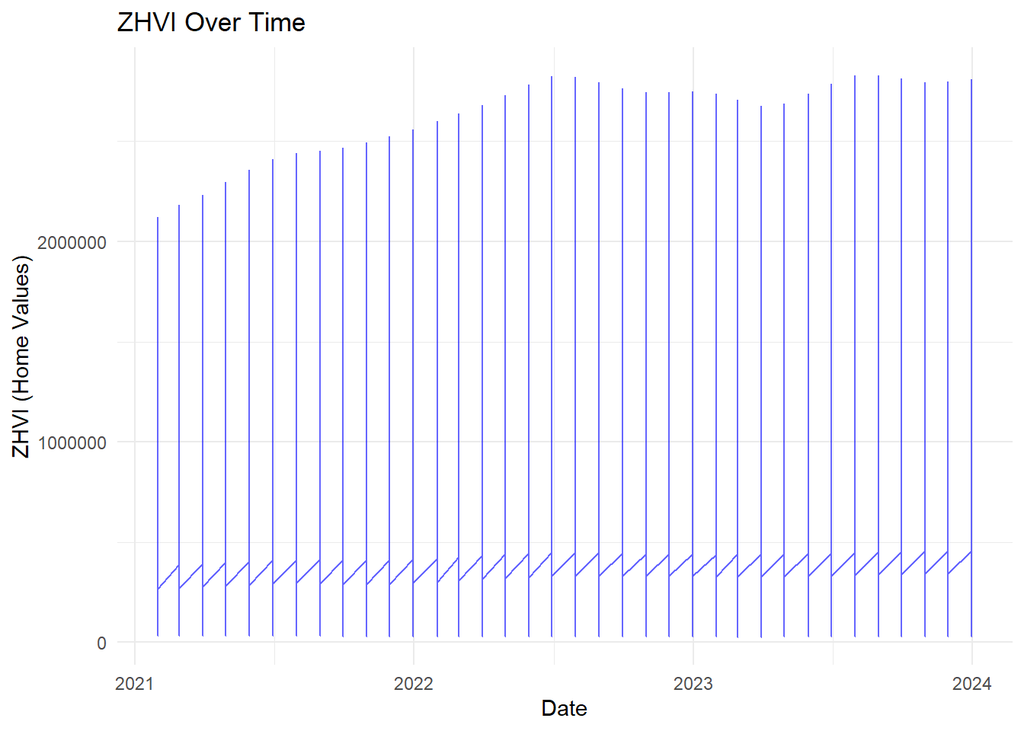

```r
# 6. Time series plot of ZHVI over time (filtered to remove NAs)
ggplot(housing_data[!is.na(housing_data$ZHVI),], aes(x = month, y = ZHVI)) +
  geom_line(color = "blue", alpha = 0.6) +
  labs(title = "ZHVI Over Time", x = "Date", y = "ZHVI (Home Values)") +
  theme_minimal()
```

It shows a clear upward trend in the Zillow Home Value Index (ZHVI) over time, indicating a rising housing market. However, there are also periods of fluctuation, suggesting that the market is not entirely stable.

# Step 13

**Correlation between SizeRank and ZHVI**

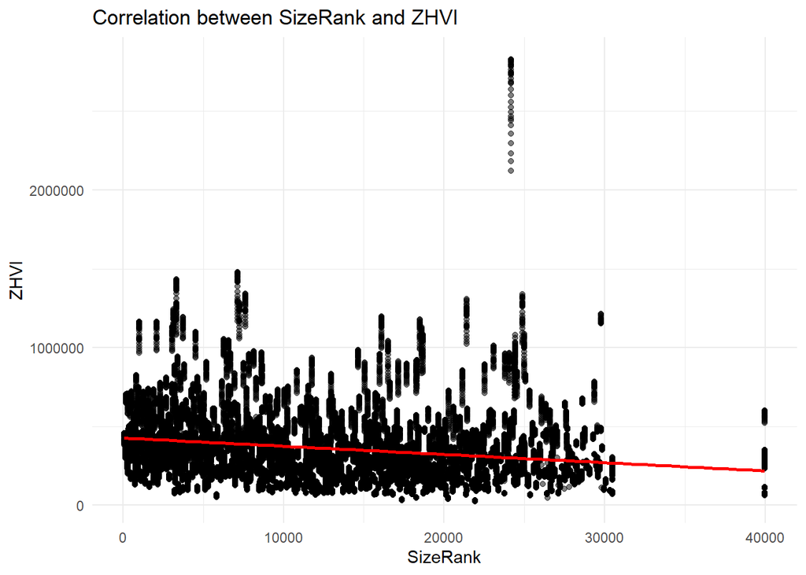

```r
# 5. Correlation between ZHVI and SizeRank
ggplot(housing_data, aes(x = SizeRank, y = ZHVI)) +
  geom_point(alpha = 0.5) +
  geom_smooth(method = "lm", color = "red") +
  labs(title = "Correlation between SizeRank and ZHVI", x = "SizeRank", y = "ZHVI") +
  theme_minimal()
```

This scatter plot indicates a negative correlation between SizeRank and ZHVI. SizeRank ranks zip codes by the average home value in a zip code related to other zip codes. So as the value for SizeRank increases, the average home value will decrease as shown in the plot. A lower SizeRank will mean a higher ZHVI. (negative correlation).

#Plotting EDA- Fardin

**Perform General EDA on the Data set**

```r
str(housing_data)
```

```
## 'data.frame':    43308 obs. of  9 variables:
##  $ RegionID  : int  67182 67732 67180 66126 66705 66843 67730 66135 67010 66683 ...
##  $ SizeRank  : int  80 140 165 174 199 268 275 277 321 322 ...
##  $ RegionName: int  22193 23464 22191 20002 20906 21234 23462 20011 21740 20878 ...
##  $ RegionType: chr  "zip" "zip" "zip" "zip" ...
##  $ State     : chr  "VA" "VA" "VA" "DC" ...
##  $ City      : chr  "Woodbridge" "Virginia Beach" "Woodbridge" "Washington" ...
##  $ Metro     : chr  "Washington-Arlington-Alexandria, DC-VA-MD-WV" "Virginia Beach-Norfolk-Newport News, VA-NC" "Washington-Arlington-Alexandria, DC-VA-MD-WV" "Washington-Arlington-Alexandria, DC-VA-MD-WV" ...
##  $ month     : Date, format: "2021-01-31" "2021-01-31" ...
##  $ ZHVI      : num  382710 298449 368262 671416 380993 ...
```

```r
library(ggplot2)
```

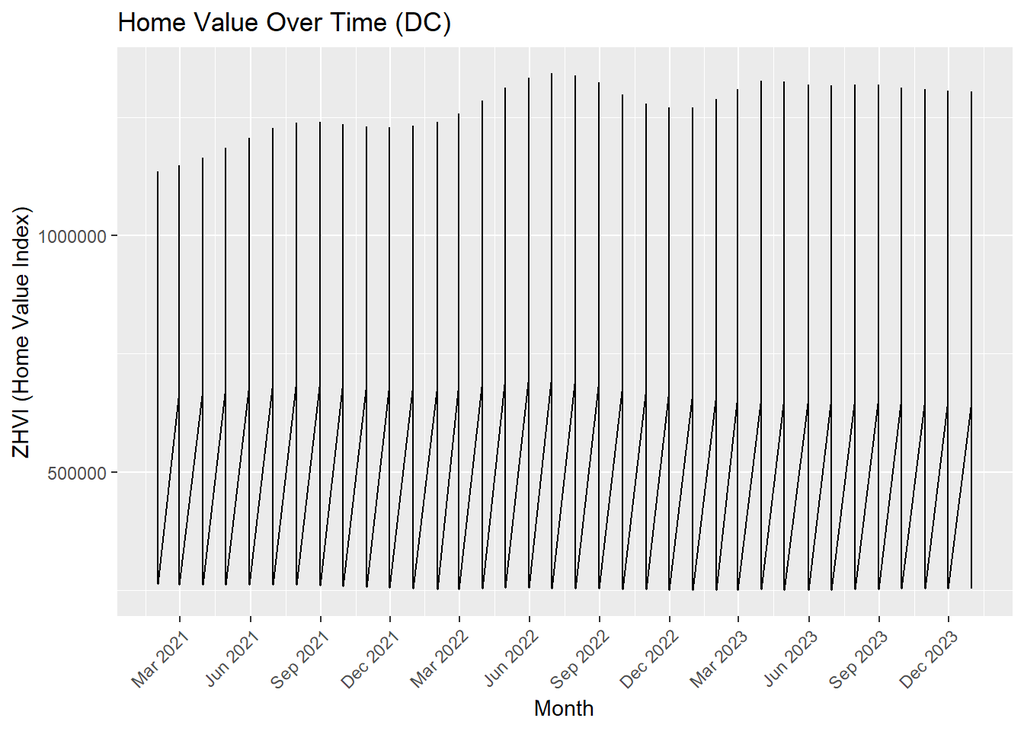

```r
dc_data$month <- as.Date(dc_data$month)
ggplot(dc_data, aes(x = month, y = ZHVI)) +
    geom_line() +
    labs(title = "Home Value Over Time (DC)", x = "Month", y = "ZHVI (Home Value Index)") +
    scale_x_date(date_labels = "%b %Y", date_breaks = "3 months") +
    theme(axis.text.x = element_text(angle = 45, hjust = 1))
```

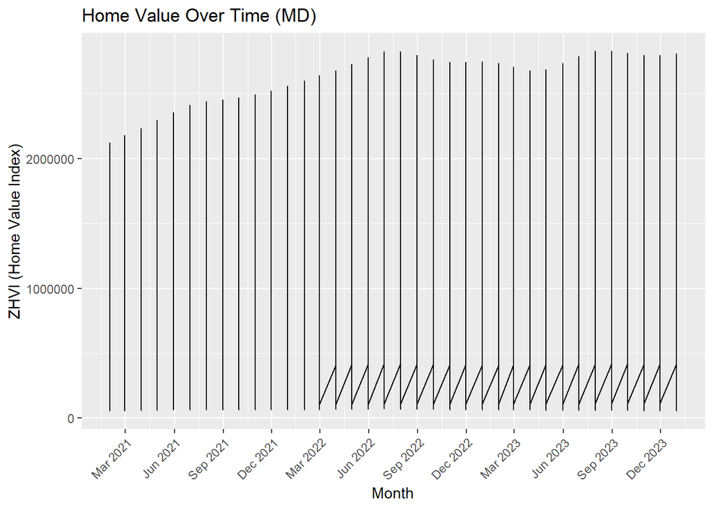

```r
md_data$month <- as.Date(md_data$month)
ggplot(md_data, aes(x = month, y = ZHVI)) +
    geom_line() +
    labs(title = "Home Value Over Time (MD)", x = "Month", y = "ZHVI (Home Value Index)") +
    scale_x_date(date_labels = "%b %Y", date_breaks = "3 months") +
    theme(axis.text.x = element_text(angle = 45, hjust = 1))
```

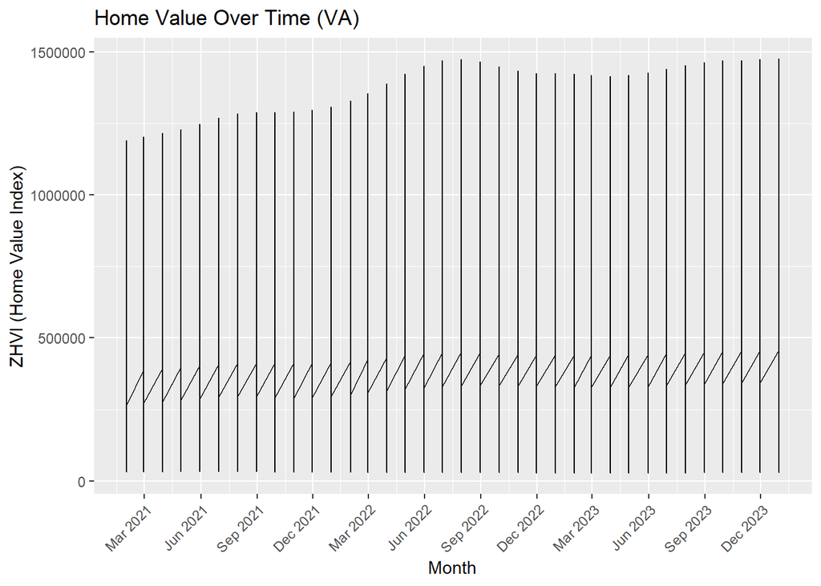

```r
va_data$month <- as.Date(va_data$month)
ggplot(va_data, aes(x = month, y = ZHVI)) +
    geom_line() +
    labs(title = "Home Value Over Time (VA)", x = "Month", y = "ZHVI (Home Value Index)") +
    scale_x_date(date_labels = "%b %Y", date_breaks = "3 months") +
    theme(axis.text.x = element_text(angle = 45, hjust = 1))
```

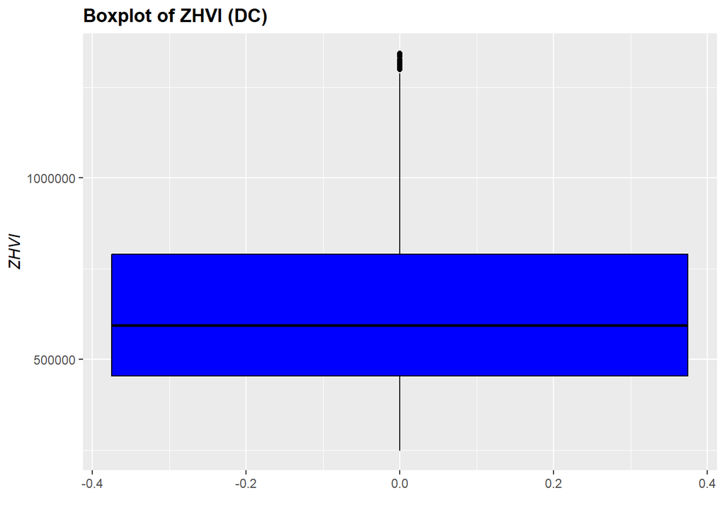

```r
ggplot(dc_data, aes(y=ZHVI)) +
  geom_boxplot( colour="black", fill="blue") +
  labs(title="Boxplot of ZHVI (DC)", x="", y = "ZHVI")+
  theme(plot.title = element_text(face = "bold"),
        axis.title.y = element_text(face = "italic"))
```

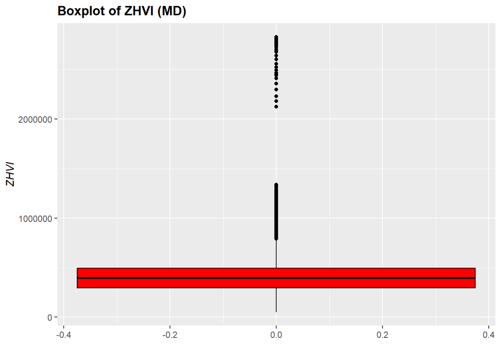

```r
ggplot(md_data, aes(y=ZHVI)) +
  geom_boxplot( colour="black", fill="red") +
  labs(title="Boxplot of ZHVI (MD)", x="", y = "ZHVI")+
  theme(plot.title = element_text(face = "bold"),
        axis.title.y = element_text(face = "italic"))
```

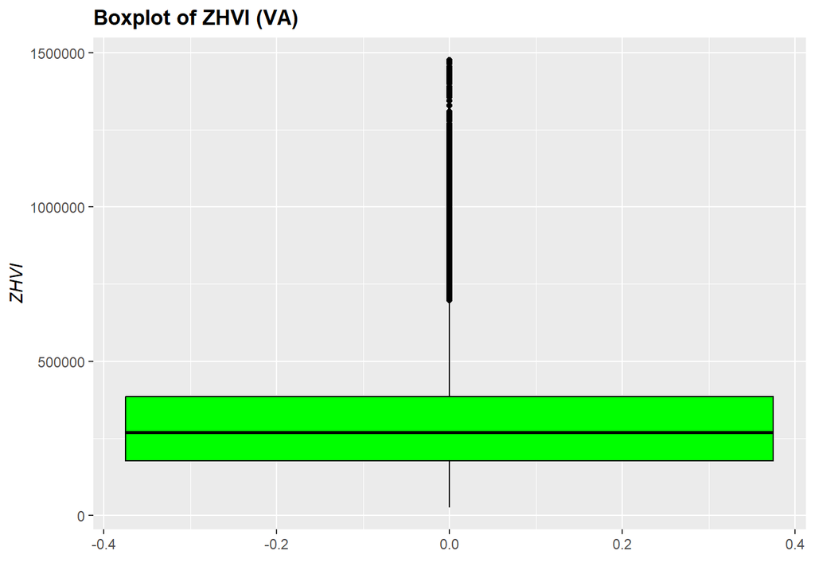

```r
ggplot(va_data, aes(y=ZHVI)) +
  geom_boxplot( colour="black", fill="green") +
  labs(title="Boxplot of ZHVI (VA)", x="", y = "ZHVI")+
  theme(plot.title = element_text(face = "bold"),
        axis.title.y = element_text(face = "italic"))
```

#Questions- Fardin

Housing prices have become a focal point of discussion in recent years, particularly in urban areas where affordability has reached critical levels. The D.C., Maryland, and Virginia (DMV) area, known for its diverse population and significant economic activity, exemplifies this trend. This project investigates the increasing housing prices in the DMV area, utilizing a dataset sourced from Zillow, a prominent online real estate marketplace. Our primary research question seeks to determine whether or not housing prices are rising in this region and how the housing prices of these regions compare against each other over time.

Zillow aggregates extensive real estate data, making it a valuable resource for analyzing housing trends across different regions. By focusing on the Zillow Home Value Index (ZHVI), which represents the market value of homes, we aim to uncover patterns in housing prices over recent years. This summary outlines the dataset’s characteristics, acknowledges its limitations, describes the data-gathering methods, reviews previous analyses, and details the exploratory data analysis (EDA) process. Additionally, it discusses how EDA influenced our research question and presents initial findings on housing price trends in the DMV area.

The topic of increasing housing prices has been a hot topic for many years due to its importance for the average American. There have already been studies that have been conducted on similar topics of housing prices but we decided to study the general trends of housing in the DMV area to make the study more localized and relevant to the area. To gain a better idea of our research question we analyzed other studies that looked at the increasing housing prices across the United States. One study that we looked at in particular for reference is an article by Goldman Sachs titled, “US house prices are forecast to rise more than 4% next year”, where it was discussed what it means that the housing prices across the United States was forecasted to increase by 4%. This was attributed to the Federal Reserve cutting interest rates and the economy being stable. This article also discussed that the unaffordability of homes is at an all-time high, which is a reason that we wanted to study this topic and this dataset. The article shows that the housing affordability index is at an all-time low at a value of about 70, in comparison to the value in 2013 which was 150. We thought that based on the current upward trends and an increasing inability for people to afford homes, it would be impactful to have our research question be based on this phenomenon.

The research we conducted on the housing price increase in the United States led us to start thinking about how this trend would look in the DMV area. Another contributing factor in our area of study was the relevance housing prices have on our current political landscape. Due to the upcoming election, there has been a lot of discourse on how housing prices are making it difficult for the average American to afford a home. There have been discussions on both sides of the election regarding how best to bridge this gap for the middle class, and this made us curious about the actual validity of these statements. We then thought of how we could go about studying the particular increase in an area and found that Zillow allows us to also sort by area. This was perfect for the development of our question because it allowed for direct isolation of the area from throughout the United States. This was pivotal as we didn’t have to sort through national data for our desired area of study. The development of the research project came fairly easily and naturally after doing the research and becoming interested on how the the trend would be reflected in the DMV area.

This dataset is taken from the online housing marketplace Zillow. Zillow is a website that facilitates the sale and purchase of real estate nationwide. The exploratory question we aimed to answer was if housing prices were increasing in the D.C., Maryland, and Virginia area (DMV), and we decided that Zillow would be a very useful tool in studying this question. Zillow records all of the purchases and sales made on the website and evaluations of homes on the market and this provides us an extensive dataset across multiple years that can be evaluated. The dataset provided a lot of valuable information about the areas of interest. The dataset was directly provided by Zillow and is publicly available for download. The dataset aims to study the idea of home value by breaking down the evaluation of property into zip codes. The dataset takes into account all of the properties and different types of properties in the area and provides a ZHVI value (Zillow Home Value Index). This ZHVI value is a measure of the home value of different homes in different percentiles of home price. We decided to use the ZHVI that measures between the 35th and 65th percentile in order to get an understanding of the general average trend of homes. ZHVI can also be specific to different types of homes like single-family, co-op, etc but we decided to include all types of homes in our dataset in order to get a full understanding of all types of homes in a specific zipcode. This dataset is updated every month but we decided to use the data from 2021-2023 in order to get a concept of the recent changes in housing prices. ZHVI is also representative of the actual housing sales and is based on a formula provided by Zillow called the Zestimate, so it is more reflective of the actual market.

Some potential limitations of this dataset should be addressed while using it. Since this dataset is provided by the popular website Zillow, it is based on the evaluation of homes listed and sold on Zillow. This tends to narrow the properties and data to those that are on Zillow. Even though Zillow does provide a good reflection of the market and landscape as a whole, not having the information from other sites and local real estate brokerages can be considered a limitation. There may be certain types of homes or types of people that list homes on Zillow, which may make the entire estimate not completely reflective of the total housing market. The data and ZHVI values are also based on a formula provided by Zillow called the Zestimate. Although this Zestimate is a well-formulated algorithm, it may provide some limitations since an estimate is not always reflective of the actual value. Another potential limitation is the NA values that are present in the dataset, which reflect values that are not available on the website. This makes it harder to evaluate some zip codes where the values are NA in later years. These limitations were mediated by having the values taken over a longer period of time so one NA would not be detrimental to the study of the trend. One way to remedy these limitations would be to take different sources of data on housing data and have a comparable value between them in order to get data from multiple sources on housing data trends.

The ZHVI is gathered by taking a general evaluation of all of the properties in an area not just the ones that have been sold. As stated on the Zillow website the ZHVI values are optimized to achieve three main objectives, timeliness, comprehensiveness, and visibility. Zillow aims to have ZHVI value readily accessible and have them be very reflective of the state of the market. Since this data is just an aggregation of data, and there is no real form of data curation, it eliminates many different types of human error that potentially be a problem with other datasets.

To better understand factors affecting home values in the provided dataset, additional information on property type (e.g., single-family homes, condos), the number of bedrooms, and property size would be beneficial. Including socioeconomic indicators, such as the average income levels of residents in each area, could offer insights into the affordability and demand drivers influencing the Zillow Home Value Index (ZHVI). Other useful data points might include crime rates, school district quality, and proximity to public transportation, as these factors often impact real estate values and demand. Weather/climate information could also provide context, especially for areas where extreme temperatures or natural disaster risks affect home desirability. Expanding the dataset with these variables would allow for a more detailed analysis of the correlations between home values and external factors, leading to a more comprehensive understanding of real estate market trends across different regions.

After conducting Exploratory Data Analysis (EDA), our research question evolved to focus more specifically on the affordability of housing in the DMV area, influenced by rising trends in home values. Initial investigations revealed significant discrepancies in home prices across different zip codes, prompting us to consider socio-economic factors that may impact affordability. The ZHVI data illustrated clear trends but also highlighted areas with considerable variability. This led us to refine our question to not only address price increases but also investigate how these changes affect the overall housing market dynamics in the region. Additionally, we recognized the importance of examining external factors like interest rates and economic policies that could further influence housing trends. Ultimately, EDA underscored the necessity of integrating additional variables like income levels and property characteristics for a more comprehensive analysis. This shift allowed us to develop a more nuanced understanding of the housing market in the DMV area.

Based on exploratory data analysis (EDA), it appears that housing prices in the D.C., Maryland, and Virginia (DMV) areas are for the most part trending upward from 2021 to 2023. However, further statistical testing revealed deeper trends. ANOVA testing on DC throughout the years 2021-2023 revealed that there is not a significant difference in the average ZHVI of the area throughout the three years. ANOVA testing on Maryland and Virginia led to different results. As mentioned before in the report, ANOVA testing revealed the average ZHVI in the state of Maryland in the year 2022 was significantly higher than in 2021. The same goes for the average ZHVI in MD from 2023 being significantly higher than 2021. However, the average ZHVI for Maryland in 2023 is not significantly higher than the average ZHVI of Maryland 2022. In Virginia, we observed that every year had a significantly difference in the average ZHVI.

However, the limitations of using Zillow’s data, such as reliance on properties listed on their platform and potential discrepancies in the Zestimate, indicate that while the data provides valuable insights, it may not fully represent the broader market dynamics. Factors like income levels, property characteristics, and local economic conditions could further elucidate the housing market trends in the DMV area. Addressing these variables through additional research could enhance the understanding of housing price fluctuations and affordability challenges in this region.

In conclusion, this exploratory data analysis of housing prices in the D.C., Maryland, and Virginia (DMV) area reveals mostly upward trends, but not all statistically significant according to Anova testing in home values over the past few years. The dataset sourced from Zillow highlights the complexities of the housing market and underscores the need for localized analysis to understand the diverse factors influencing affordability and access to housing.

While the ZHVI data indicates a general rise in housing prices, it also points to considerable variability across different zip codes, suggesting that not all areas are experiencing these changes uniformly. The findings align with broader national trends, yet they also highlight the unique characteristics of the DMV market, influenced by local economic conditions and demographic shifts.

Moving forward, our research will continue to refine the analysis by incorporating additional socio-economic variables and examining the impacts of rising housing prices on various demographics. Understanding these dynamics is crucial for informing policy discussions and addressing the growing concerns surrounding housing affordability in the DMV area. By delving deeper into the underlying factors driving these trends, we aim to contribute valuable insights that can support effective solutions for the region’s housing challenges.

References (APA style preferred) Dworkin, D. M. (2024, September 4). The Harris-Walz Housing Plan - detailed, serious, and impactful. National Housing Conference. https://nhc.org/the-harris-walz-housing-plan-detailed-serious-and-impactful/

Olsen, S. (2023, February 11). Zillow Home Value Index Methodology, 2023 revision: What’s changed? Zillow. https://www.zillow.com/research/methodology-neural-zhvi-32128/

US house prices are forecast to rise more than 4% next year. Goldman Sachs. (2024, September 11). https://www.goldmansachs.com/insights/articles/us-house-prices-are-forecast-to-rise-more-than-4-percent-next-year